# United Nations Voting Patterns

Dr. Grant Innerst

2020-01-12

In this document we are going to take a look at the voting patterns of the United Nations General Assembly. The data that we are going to use is from the **unvotes** package. There are additional packages that we will make use of to do our data analysis. These packages are loaded below in what is called an R code chunk:

```r
library("unvotes")
library("tidyverse")
library("lubridate")
library("DT")
```

## Data Description

The **unvotes** package contains 3 datasets. The first dataset, named `un_votes`, contains the history of each country’s vote. There is one row for each country/vote pair.

```r
un_votes
```

```
## # A tibble: 738,764 x 4
##     rcid country                  country_code vote
##    <int> <chr>                    <chr>        <fct>
##  1     3 United States of America US           yes
##  2     3 Canada                   CA           no
##  3     3 Cuba                     CU           yes
##  4     3 Haiti                    HT           yes
##  5     3 Dominican Republic       DO           yes
##  6     3 Mexico                   MX           yes
##  7     3 Guatemala                GT           yes
##  8     3 Honduras                 HN           yes
##  9     3 El Salvador              SV           yes
## 10     3 Nicaragua                NI           yes
## # … with 738,754 more rows
```

The second dataset, named `un_roll_calls`, contains information about each roll call vote, including the date, description, and resolution that was voted on.

```r
un_roll_calls
```

```
## # A tibble: 5,429 x 9
##     rcid session importantvote date       unres  amend  para short  descr
##    <int>   <dbl>         <dbl> <date>     <chr>  <dbl> <dbl> <chr>  <chr>
##  1     3       1             0 1946-01-01 R/1/66     1     0 AMEND… TO ADO…
##  2     4       1             0 1946-01-02 R/1/79     0     0 SECUR… TO ADO…
##  3     5       1             0 1946-01-04 R/1/98     0     0 VOTIN… "TO AD…
##  4     6       1             0 1946-01-04 R/1/1…     0     0 DECLA… TO ADO…
##  5     7       1             0 1946-01-02 R/1/2…     1     0 GENER… "TO AD…
##  6     8       1             0 1946-01-05 R/1/2…     1     0 ECOSO… TO ADO…
##  7     9       1             0 1946-02-05 R/1/3…     0     0 POST-… TO OPE…
##  8    10       1             0 1946-02-05 R/1/3…     1     1 U.N. … "TO AD…
##  9    11       1             0 1946-02-05 R/1/3…     0     0 TRUST… TO ADO…
## 10    12       1             0 1946-02-06 R/1/3…     1     1 COUNC… TO ADO…
## # … with 5,419 more rows
```

The third dataset, named `un_roll_call_issues`, shows the relationships between each vote and 6 different issues.

```r
un_roll_call_issues
```

```
## # A tibble: 5,281 x 3
##     rcid short_name issue
##    <int> <chr>      <chr>
##  1  3372 me         Palestinian conflict
##  2  3658 me         Palestinian conflict
##  3  3692 me         Palestinian conflict
##  4  2901 me         Palestinian conflict
##  5  3020 me         Palestinian conflict
##  6  3217 me         Palestinian conflict
##  7  3298 me         Palestinian conflict
##  8  3429 me         Palestinian conflict
##  9  3558 me         Palestinian conflict
## 10  3625 me         Palestinian conflict
## # … with 5,271 more rows
```

So what are the issues?

```r
count(un_roll_call_issues, issue, sort = TRUE)
```

```
## # A tibble: 6 x 2
##   issue                                    n
##   <chr>                                <int>
## 1 Palestinian conflict                  1104
## 2 Colonialism                            991
## 3 Human rights                           986
## 4 Arms control and disarmament           956
## 5 Nuclear weapons and nuclear material   762
## 6 Economic development                   482
```

## Analysis

Let’s make a cool visualization!! I am interested in how often certain countries voted “Yes” on a resolution each year. First, let’s pick the countries we are interested in showing.

```r
countries <- c("United States of America", "Italy", "Russian Federation", "Cuba")
```

Let’s make a plot (and do some work to get there)!

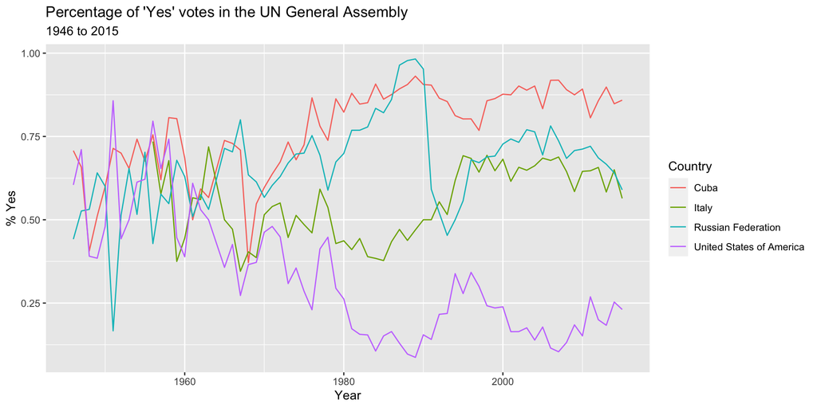

```r
un_votes %>%
  filter(country %in% countries) %>%
  inner_join(un_roll_calls, by = "rcid") %>%
  group_by(year = year(date), country) %>%
  summarize(
    votes = n(),
    percent_yes = mean(vote == "yes")
    ) %>%
  ggplot(mapping = aes(x = year, y = percent_yes, color = country)) +
    geom_line() +
    labs(
      title = "Percentage of 'Yes' votes in the UN General Assembly",
      subtitle = "1946 to 2015",
      y = "% Yes",
      x = "Year",
      color = "Country"
    )
```

Now let’s take a look at how the voting behaviors have changed per year for each of the issues. We will look at the United States and Russia. Here’s the plot and the work to get to it!

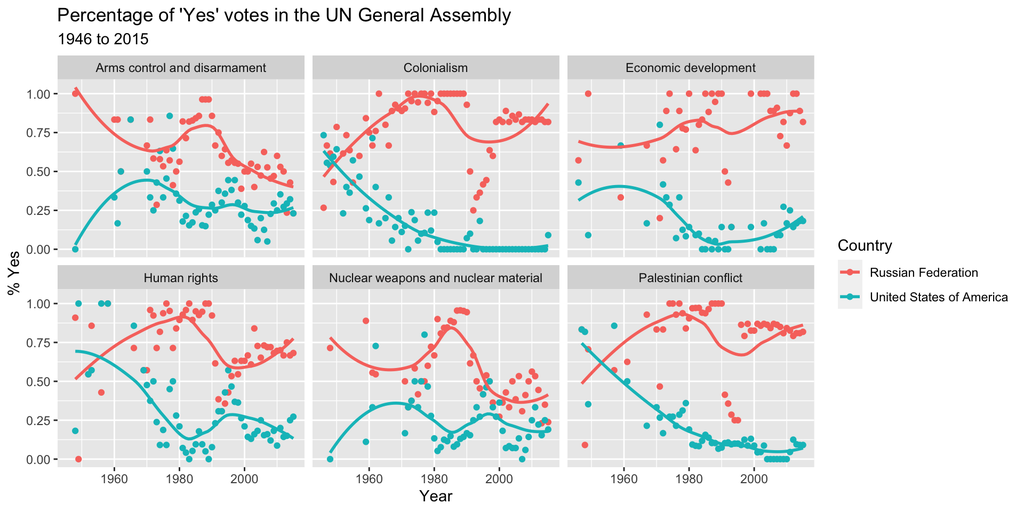

```r
un_votes %>%
  filter(country %in% c("United States of America", "Russian Federation")) %>%
  inner_join(un_roll_calls, by = "rcid") %>%
  inner_join(un_roll_call_issues, by = "rcid") %>%
  group_by(country, year = year(date), issue) %>%
  summarize(
    votes = n(),
    percent_yes = mean(vote == "yes")
    ) %>%
  filter(votes > 5) %>%  # only use records where there are more than 5 votes
  ggplot(mapping = aes(x = year, y = percent_yes, color = country)) +
    geom_point() +
    geom_smooth(method = "loess", se = FALSE) +
    facet_wrap(~ issue) +
    labs(
      title = "Percentage of 'Yes' votes in the UN General Assembly",
      subtitle = "1946 to 2015",
      y = "% Yes",
      x = "Year",
      color = "Country"
    )
```

This analysis is a good example of code that can be easily altered to tell a totally different story. You just need to change which countries are being `filter`ed.

**Assignment**: Change the names in both plots to explore some other relationships. Mkae sure to spell the new country names exactly as they appear in the data (R is case sensitive). See the Appendix for a list of the countries in the data.

## References

1. David Robinson (2017). unvotes: United Nations General Assembly Voting Data. R package version 0.2.0. https://CRAN.R-project.org/package=unvotes.
2. Erik Voeten “Data and Analyses of Voting in the UN General Assembly” Routledge Handbook of International Organization, edited by Bob Reinalda (published May 27, 2013).
3. Much of the analysis has been modeled on the examples presented in the [unvotes package vignette](https://cran.r-project.org/web/packages/unvotes/vignettes/unvotes.html).
4. This has been further altered from the material from the [data science box](https://github.com/rstudio-education/datascience-box)

## Appendix

Below is a list of countries in the dataset:

```r
un_votes %>%
  select(country) %>%
  arrange(country) %>%
  distinct() %>%
  datatable()
```

|  | country |
| --- | --- |
| 1 | Afghanistan |
| 2 | Albania |
| 3 | Algeria |
| 4 | Andorra |
| 5 | Angola |
| 6 | Antigua and Barbuda |
| 7 | Argentina |
| 8 | Armenia |
| 9 | Australia |
| 10 | Austria |

[output cut: 190 more lines]